# RSV (AREXVY) - Atrial fibrillation

OpenSourcePV

Data Lock Point: Data contains VAERS reports processed as of 2023_12_29 (Year_Month_Day). Flag NEW was defined against reports processed as of 2023_11_24.

# 1 Quantitative Signal status

## 1.1 Disproportionality

The vaccine-event combination “RSV (AREXVY) - Atrial fibrillation” was **a signal of disproportionate reporting** with an EB05 value of 2.92.

The threshold for being flagged as a signal of disproportionate reporting is an EB05>=2 meaning that there there is a 95% probability that the reporting of Atrial fibrillation was at least twice post exposure to RSV (AREXVY) than post all vaccines [1]. Under the assumption of no causality between RSV (AREXVY) and Atrial fibrillation and no bias it would have been expected to observe an EBGM of 1.

It means that the quantified causality criterion of strength of association is **met**.

*It is to be noted that the nature of the spontaneous report does not provide reliable estimates of the strength of association (whatever the choice of the disproportionality method) and that some reporting bias or difference in demographic characteristics might explain the (un)observed disproportion*.

## 1.2 Time-to-onset

The vaccine-event combination “RSV (AREXVY) - Atrial fibrillation” was **not a signal of unexpected time-to-onset distribution** with a p-value of the two-sample Kolmogorov-Smirnov test being 0.0528039 and distance between the two empirical cumulative distributions being of 30.2285714%.

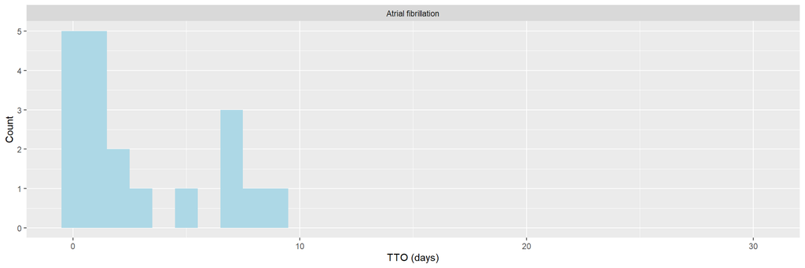

The TTO signal detection method tests if the distribution of Atrial fibrillation post RSV (AREXVY) is significantly different from the distribution of Atrial fibrillation post other vaccines using a two-sample Kolmogorov-Smirnov test [2]. The threshold for being flagged as a signal of unexpected time-to-onset distribution is a P-value <0.001 and a distance between the two empirical distributions larger than 20%. Under the assumption of no causality and no bias, it would have been expected that the time-to-onset distribution for “Atrial fibrillation” would have been the same post RSV (AREXVY) than post other vaccines.

It means that the quantified causality criterion of temporality is **not met**.

*It is to be noted that the nature of the spontaneous report does not provide reliable estimates of the temporal relationship between the exposure and the occurrence of the events as there is the reporting bias over time: the latter the event occurs after exposure, the less chance it has to be reported. Other biases could distort the reported time-to-onset distribution (media attention, etc.)*

## 1.3 Overall

Based on the screening of the Empirical Bayes Geometric Mean (EBGM) and the screening of the time-to-onset distribution,the vaccine-event combination “RSV (AREXVY) - Atrial fibrillation” is **considered as quantitative signal**.

# 2 Signal History

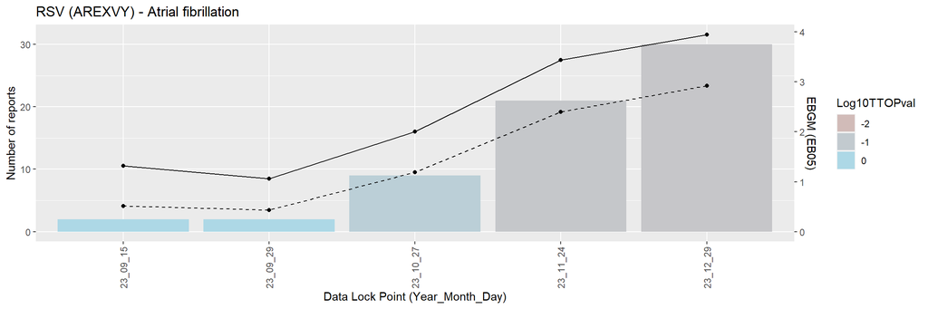

# 3 Case series

## 3.1 Seriousness

A total of 30 reports of Atrial fibrillation were received post exposure to RSV (AREXVY). Among them:

- 0 (0.0 %) were fatal cases.
- 1 (3.3 %) were life threatening cases.
- 4 (13.3 %) were hospitalized cases.
- 0 (0.0 %) were emergency room cases.
- 0 (0.0 %) were cases with disabilies.

9 new cases were received since last data refresh.

## 3.2 Demographic characteristics

30 cases of Atrial fibrillation post RSV (AREXVY) were reported in VAERS:

- Among them, there were 13 (43.3%) female cases and 8 (26.7%) male cases while the overall female:male ratio is 68:26%.
- The mean (median) age for patients presenting symptoms of Atrial fibrillation was 73 (72) years while the overall mean (median) age was 71 (71) years.
- The top 5 contributing US states for patients presenting symptoms of Atrial fibrillation were NA ( 33.3 %) , FL ( 10 %) , IL ( 10 %) , CA ( 6.7 %) , MN ( 6.7 %) while overall the top 5 of contributing US states are NA ( 11.9 %) , FL ( 9.2 %) , CA ( 8.4 %) , NY ( 5.7 %) , TX ( 4.5 %)

# 4 Listing of the cases

Narratives can be made visible clicking on the ⊕ symbol.

|  | VAERS ID | Sex/Age (Years) | Receipt Date | Seriousness status | List of symptoms | New | SYMPTOM_TEXT |
| --- | --- | --- | --- | --- | --- | --- | --- |
| &oplus; | 2720032 | M/64 | 12/01/2023 |  | Atrial fibrillation, Condition aggravated | Yes | Received both vaccines Friday morning Overnight that night began experiencing A fib for the first time in over 2 years Doctor prescribed Metoprolol tartrate once per day and monitored until November 2… |
| &oplus; | 2721356 | F/82 | 12/06/2023 |  | Atrial fibrillation, Condition aggravated, Dyspnoea, Fatigue, Feeling abnormal, Malaise, Muscle discomfort, Pain, Somnolence | Yes | RSV recombinant protein subunit RSVpreF adjuvant incoming vaccine info from the state health department given at the local pharmacy per patient report on 11 25 2023 Chart updated with state vaccine re… |
| &oplus; | 2722211 | M/67 | 12/08/2023 | Hospitalized | Atrial fibrillation | Yes | Atrial Fibrillation |
| &oplus; | 2724564 | F/NA | 12/15/2023 |  | Atrial fibrillation, Condition aggravated, Heart rate increased, Heart rate irregular | Yes | Fast irregular heart rate Fast irregular heart rate Atrial fibrilation This serious case was reported by a consumer and described the occurrence of atrial fibrillation in a 73 year old female patient … |
| &oplus; | 2724566 | U/NA | 12/15/2023 |  | Atrial fibrillation, Condition aggravated | Yes | multiple years of afib This serious case was reported by a consumer via regulatory authority and described the occurrence of atrial fibrillation in a patient who received RSVPreF3 adjuvanted Arexvy fo… |
| &oplus; | 2725144 | U/NA | 12/18/2023 |  | Atrial fibrillation | Yes | Atrial fibrillation This serious case was reported by a consumer via regulatory authority and described the occurrence of atrial fibrillation in a patient who received RSVPreF3 adjuvanted Arexvy for p… |
| &oplus; | 2725564 | U/NA | 12/19/2023 |  | Atrial fibrillation | Yes | Developed atrial fibrillation This serious case was reported by a physician via sales rep and described the occurrence of atrial fibrillation in a patient who received RSVPreF3 adjuvanted Arexvy for p… |
| &oplus; | 2726300 | F/79 | 12/21/2023 |  | Atrial fibrillation | Yes | pt developed afib shortly after her immunization and read that this was described in the package insert wanted her experience recorded |
| &oplus; | 2727346 | F/64 | 12/26/2023 |  | Atrial fibrillation, Condition aggravated | Yes | Pt called stating that after receiving the vaccine they have been experiencing more episodes of Afib than prior Now episodes are occurring nightly Patient advised to let her doctor know as well |
| &oplus; | 2680502 | F/65 | 09/08/2023 |  | Atrial fibrillation, Heart rate irregular | No | IRREGULAR HEART BEATS AND A FIB |

[output cut: 20 more lines]

# 5 Disclaimer

This analysis is exploratory only and authors cannot be held responsible for any decision made using these data. It is important to distinguish quantitative signals such as disproportionate reporting, unexpected time-to-onset patterns or cluster from safety signals. Only a qualitative review using multiple data source (literature, clinical trials, etc.) and multiple causality criteria assessment could qualify quantitative signals into safety signals.

# 6 References

[1] Dumouchel W. Bayesian data mining in large frequency tables, with an application to the FDA spontaneous reporting system. Am Stat 1999; 53: 177–190.

[2] Van Holle L et al, Using time‐to‐onset for detecting safety signals in spontaneous reports of adverse events following immunization: a proof-of-concept study. Pharmacoepidemiology and Drug Safety 21 (6), 603-610.